# STATS 32 Session 10: A Crash Course in Statistics and Modeling

Kenneth Tay

Oct 24, 2019

# Announcements

Project due on **2 Nov (Sat) 23:59:59**

Remaining office hours:

- 25 Oct (tomorrow)
- 1 Nov (next Friday)

10am-12pm, Sequoia Hall Rm 105

# Recap of session 9

- Joining datasets with `left_join`
  - `df1 %>% left_join(df2, by = "key")`
- Making maps in R
  - `geom_polygon()`
  - `aes(x = long, y = lat, group = group)`

# Agenda for today

- A crash course in statistics and modeling
  - Hypothesis testing
  - Linear regression

A very high level picture: for technical details, take STATS 60/STATS 101

# Recall: Lists

```r
cars <- list(make = "Honda",
             models = c("Fit", "CR-V", "Odyssey"),
             available = c(TRUE, TRUE, TRUE))
```

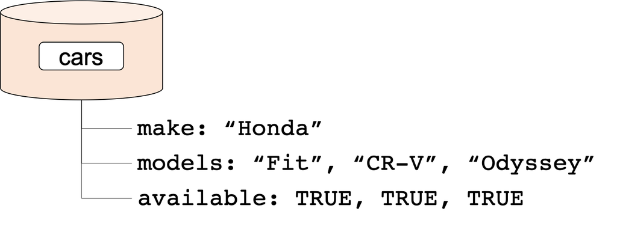

# Extracting parts of a list

Use `[[` or `$` notation to refer to a specific key-value pair

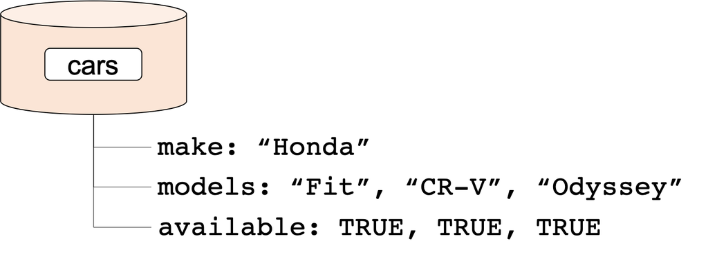

```r
cars$make         # no quotation marks
```

```
## [1] "Honda"
```

```r
cars[["models"]]  # remember quotation marks!
```

```
## [1] "Fit"     "CR-V"    "Odyssey"
```

# Recall: Data frames are lists!

- To R, a data frame is simply a special type of list!
  - Keys of the list are the variable/covariate names
  - Values are vectors of the same length

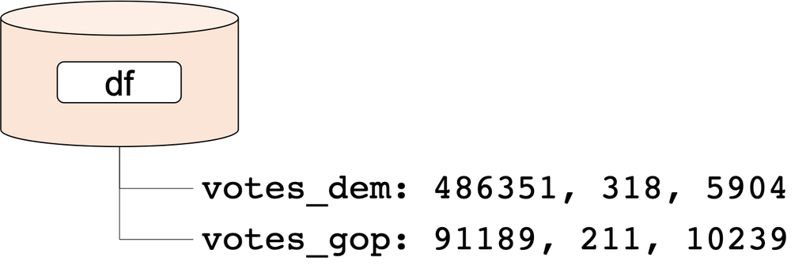

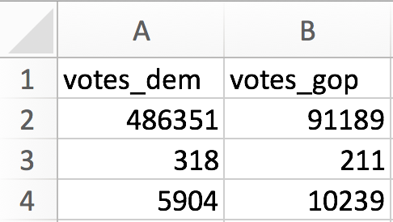

# Today’s dataset: Top 100 songs on Spotify

[figure not shown]

(Source: [Spotify](https://open.spotify.com/playlist/37i9dQZF1DX7Axsg3uaDZb))

# Tempo by mode: Is there a difference?

Hard to tell from the histograms:

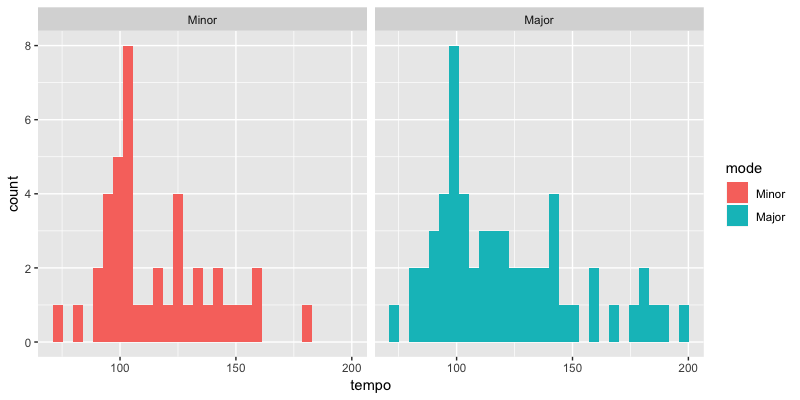

# Look at mean tempo for each mode

- Major: $\approx 122$ bpm
- Minor: $\approx 116$ bpm

Is this difference significant? What do we mean by significance anyway?

# Structure of a hypothesis test

1. Start with a **null hypothesis**: An assumption on how the data is generated

# Structure of a hypothesis test

1. Start with a **null hypothesis**: An assumption on how the data is generated
2. Based on this assumption, how likely were we to collect data as extreme as what we have?
   - **p-value**: probability of collecting data as extreme as ours (if null hypothesis is true)

# Structure of a hypothesis test

1. Start with a **null hypothesis**: An assumption on how the data is generated
2. Based on this assumption, how likely were we to collect data as extreme as what we have?
   - **p-value**: probability of collecting data as extreme as ours (if null hypothesis is true)
3. Is the p-value considered low or not?
   - Threshold should depend on the context
   - Typical thresholds, 0.1, 0.05, 0.01

# Structure of a hypothesis test

1. Start with a **null hypothesis**: An assumption on how the data is generated
2. Based on this assumption, how likely were we to collect data as extreme as what we have?
   - **p-value**: probability of collecting data as extreme as ours (if null hypothesis is true)
3. Is the p-value considered low or not?
   - Threshold should depend on the context
   - Typical thresholds, 0.1, 0.05, 0.01
4. If p-value is below threshold, 2 possible conclusions:
   - A rare event just happened, or
   - Our assumption in Step 1 was false

# Hypothesis test: coin flipping example

I flip a coin 20 times and it came out heads 16 times. **Is my coin biased?**

# Hypothesis test: coin flipping example

I flip a coin 20 times and it came out heads 16 times. **Is my coin biased?**

1. Start with a **null hypothesis**: Probability of heads $p = 0.5$

# Hypothesis test: coin flipping example

I flip a coin 20 times and it came out heads 16 times. **Is my coin biased?**

1. Start with a **null hypothesis**: Probability of heads $p = 0.5$
2. Based on this assumption, how likely were we to collect data as extreme as what we have?
   - “As extreme”: 16 or more heads, or 4 or less heads
   - Probability of collecting data as extreme as ours: 0.0118

# Hypothesis test: coin flipping example

I flip a coin 20 times and it came out heads 16 times. **Is my coin biased?**

1. Start with a **null hypothesis**: Probability of heads $p = 0.5$
2. Based on this assumption, how likely were we to collect data as extreme as what we have?
   - “As extreme”: 16 or more heads, or 4 or less heads
   - Probability of collecting data as extreme as ours: 0.0118
3. Is the p-value considered low or not?

# Hypothesis test: coin flipping example

I flip a coin 20 times and it came out heads 16 times. **Is my coin biased?**

1. Start with a **null hypothesis**: Probability of heads $p = 0.5$
2. Based on this assumption, how likely were we to collect data as extreme as what we have?
   - “As extreme”: 16 or more heads, or 4 or less heads
   - Probability of collecting data as extreme as ours: 0.0118
3. Is the p-value considered low or not?
4. If p-value is below threshold, 2 possible conclusions:
   - A rare event just happened, or
   - Our assumption in Step 1 was false

# Tempo by mode: Is there a difference?

Two options:

- $t$-test
  - **Null hypothesis**: Mean tempo for songs in minor key is the same as that for songs in major key
  - Makes more assumptions on the data generation process (“*parametric* test”)

# Tempo by mode: Is there a difference?

Two options:

- $t$-test
  - **Null hypothesis**: Mean tempo for songs in minor key is the same as that for songs in major key
  - Makes more assumptions on the data generation process (“*parametric* test”)
- Kolmogorov-Smirnov test
  - **Null hypothesis**: The distribution of tempo for songs in minor key is the same as that for songs in major key
  - Less assumptions on data generation process (“*non-parametric* test”), but rejecting the null gives less information

# What is a model?

- A **model** is a simplified and idealized way to understand a system.
- [R4DS](http://r4ds.had.co.nz/model-intro.html): “The goal of a model is to provide a simple low-dimensional summary of a dataset. Ideally, the model will capture true “signals” (i.e. patterns generated by the phenomenon of interest), and ignore “noise” (i.e. random variation that you’re not interested in)."

# Two steps to modeling

### Step 1: Identify a family of models which express a generic pattern between your variables of interest.

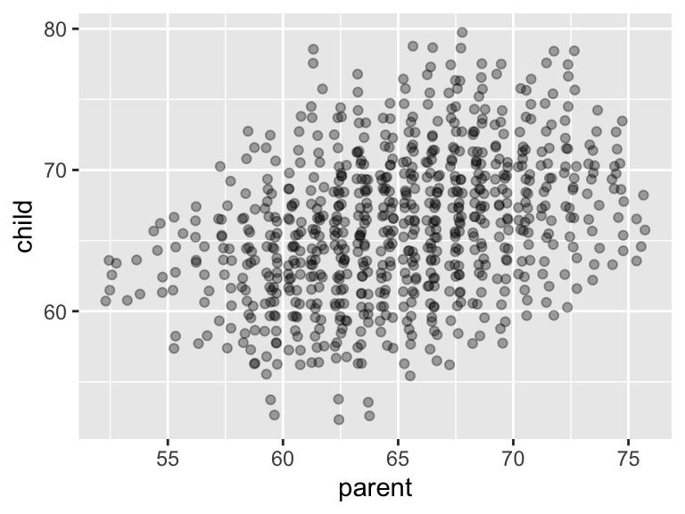

Possible model family: Linear model, i.e. $child = a_1 + a_2 \times parent$.

- Variables: `child` and `parent`
- Model parameters: $a_1$ and $a_2$

Many other possible models: linear without intercept, quadratic, exponential, …

# Different models within the linear model family

Each line corresponds to a choice of $a_1$ and $a_2$.

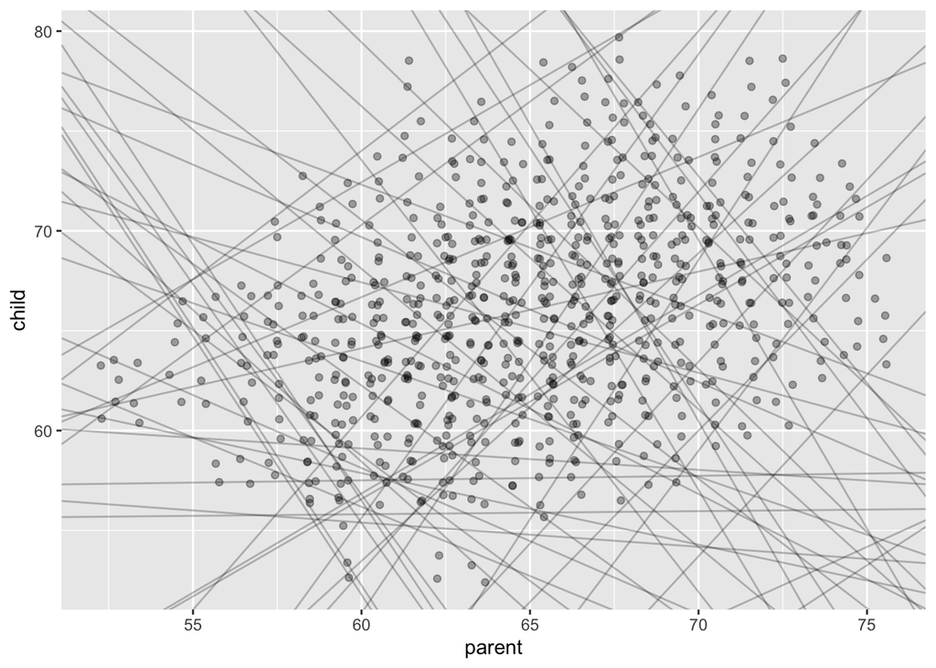

# Two steps to modeling

### Step 2: Find the model in this family that most closely matches your data.

That is, find specific values of $a_1$ and $a_2$ which make the model match the data most closely.

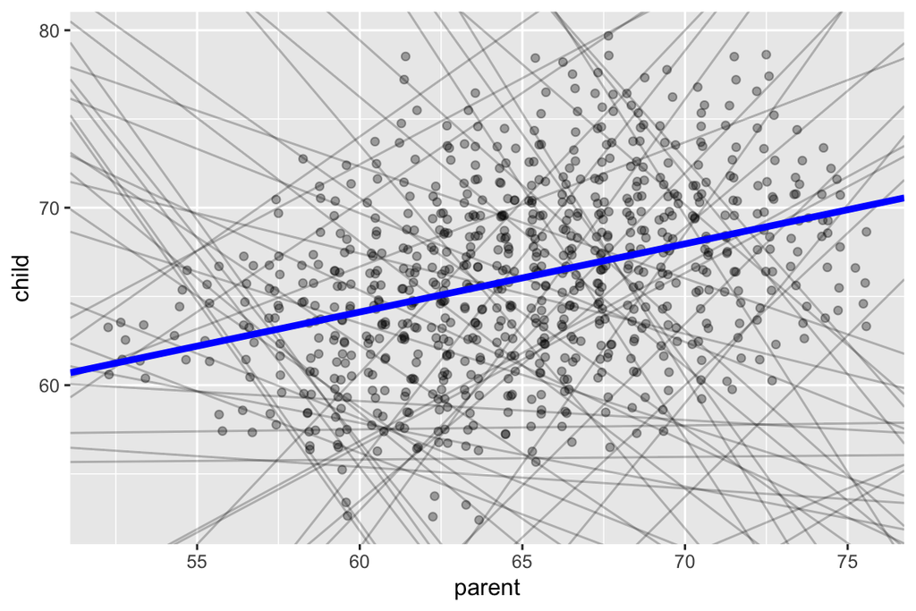

# What do we mean by “closely matching the data”?

We choose $a_1$ and $a_2$ such that some objective function (**loss function**) is minimized.

Most common objective: Minimize the sum of squares of the black lines below.

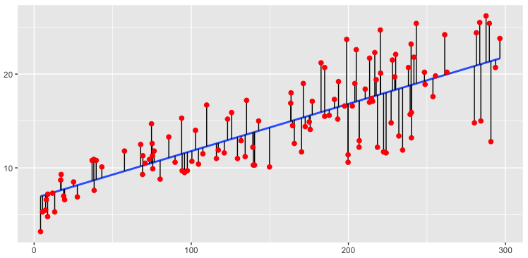

(Source: [uc-r.github.io](http://uc-r.github.io/linear_regression))

# Linear models in R

- Linear regression can be done with the `lm` function
- Syntax: `lm(formula, data = df)`
- Formulas look like `y ~ x`, which `lm` will translate to a function like $y = a_1 + a_2 \cdot x$

# Models with categorical variables

Consider modeling `valence ~ mode`.

- Does the model $valence = a_1 + a_2 \cdot mode$ make sense?
  - 3 + 4 $\cdot$ “Major”??
- What R does:
  - Choose a baseline category (say, “Minor”)
  - Model $valence = a_1 + a_2 \cdot modeMajor$, where $modeMajor = \begin{cases} 1 &\text{if "Major"}, \\ 0 &\text{if "Minor"}. \end{cases}$
- $valence = a_1$ if Minor, $valence = a_1 + a_2$ if Major

# Additive models

Formula `valence ~ loudness + mode` translates to

- $valence = a_1 + a_2 \cdot loudness + a_3 \cdot modeMajor$, where $modeMajor = \begin{cases} 1 &\text{if "Major"}, \\ 0 &\text{if "Minor"}. \end{cases}$
- $valence = a_1 + a_2 \cdot loudness$ if Minor
- $valence = (a_1 + a_3) + a_2 \cdot loudness$ if Major
- Same gradient, different intercept

# Models with interaction

Formula `valence ~ loudness * mode` translates to

- $valence = a_1 + a_2 \cdot loudness + a_3 \cdot modeMajor + \color{blue}{a_4 \cdot loudness \cdot modeMajor}$, where $modeMajor = \begin{cases} 1 &\text{if "Major"}, \\ 0 &\text{if "Minor"}. \end{cases}$
- $valence = a_1 + a_2 \cdot loudness$ if Minor
- $valence = (a_1 + a_3) + (a_2 + a_4) \cdot loudness$ if Major
- Different gradient, different intercept

# Summary of the course

- Variable types
- Basic objects in R (vectors, lists, data frames)
- Plotting data with `ggplot2`
- Transforming and joining data with `dplyr` and `tidyr`
- Importing and exporting data
- Working with factors using `forcats`
- R scripts and R markdown
- Making maps
- Basic statistical testing and modeling

# Where do we go from here?

- Read [R for Data Science](http://r4ds.had.co.nz/) from cover to cover!
- Go through the programming exercises and solutions
- Take short courses on [DataCamp](https://www.datacamp.com/onboarding/learn?from=home&technology=r)
- Writing your own functions and running simulations
- Interactive plots with `plotly`
- Advanced mapping with `ggmap`
- Predictive models/machine learning with `caret`
- Interactive web apps with `shiny`
- Text analysis with `tidytext`
  - Recommmended text: *Text Mining with R* by Julia Silge and David Robinson (avaible online for free at [tidytextmining.com](http://tidytextmining.com/))

# Other Stanford courses

- Programming: CS 106A
- Statistical methods: STATS 60, STATS 101
- Data challenge lab: ENGR 150

# Thank you! :)